# Combine two Zhang samples

Alexey Larionov

24 Feb 2021

# 1 Summary

- Read source data
  - 655 genes with coordinates: alteady in GRanges (using Seqinfo(genome="hg38"))
  - Zhang sample: convert to GRanges using the same Seqinfo as in the 655 genes
  - Summarized Experiment, made previously from GRanges in RMS progect
- Preprocess new GRange
  - Select variants on standard chromosomes
  - Select variants overlapping with 655 genes
  - Exclude common variants (MAF > 0.05)
- Split GR and SE to subsets
  - Make Chr_Start_End_Ref_Alt key in GRanges
  - Make subsets: unique for GR, SE and overlap of GR and SE
- Select variant annotations
  - Make vector of stable variant annotations that is keept in GRanges
  - Make NA matrices for sample-specific variant annotations
- Process variants unique for GR and SE
  - Make GRanges for unique GR and SE
  - Capture sample-specific annotations to the matrices
- Porcess overlapping variants in GR and SE
  - Make GRange for intersect of GR and SE
  - Capture sample-specific annotations to the matrices
- Combine all variants
  - Merge unique and overlapping GRanges
  - Sort the merged GRanges
  - Sync matrices rows with the sorted GRanges
- Save to the new SummarisedExperiment

# 2 Start section

```r
# Time stamp
Sys.time()
```

```
## [1] "2021-02-25 14:52:33 GMT"
```

```r
# Clenan-up
rm(list=ls())
graphics.off()

# Memory
gc()
```

```
##          used (Mb) gc trigger (Mb) limit (Mb) max used (Mb)
## Ncells 415191 22.2     865501 46.3         NA   641517 34.3
## Vcells 789517  6.1    8388608 64.0      16384  1768559 13.5
```

```r
# Options
options(stringsAsFactors=F)

# Files and folders
base_folder <- "/Users/alexey/Documents/mg/s2021/zhang_tests"
data_folder <- file.path(base_folder,"data","s06_combine_samples")
scripts_fiolder <- file.path(base_folder,"scripts","s06_combine_samples")
setwd(scripts_fiolder)

# Libraries
library(GenomicRanges)
library(VennDiagram)
library(SummarizedExperiment)
```

# 3 Read data

## 3.1 655 (of 667) genes

```r
# Load data
load(file.path(base_folder,"scripts","s04_gene_list_with_coordinates","s03_667_gene_coordinates.RData"))

# Remove unnecessary objects
rm(working_folder,absent_genes_9.df,genes_628.gr,genes_658.grl,genes_667.df,
   multi_genes_3.df, multi_genes_3.grl,multi_genes_30.df,multi_genes_30.grl)

# Update folders
base_folder <- "/Users/alexey/Documents/mg/s2021/zhang_tests"
data_folder <- file.path(base_folder,"data","s06_combine_samples")
scripts_fiolder <- file.path(base_folder,"scripts","s06_combine_samples")

# Check the genes list
summary(genes_655.gr)
```

```
## [1] "GRanges object with 655 ranges and 2 metadata columns"
```

```r
seqinfo(genes_655.gr)
```

```
## Seqinfo object with 25 sequences (1 circular) from hg38 genome:
##   seqnames seqlengths isCircular genome
##   chr1      248956422      FALSE   hg38
##   chr2      242193529      FALSE   hg38
##   chr3      198295559      FALSE   hg38
##   chr4      190214555      FALSE   hg38
##   chr5      181538259      FALSE   hg38
##   ...             ...        ...    ...
##   chr21      46709983      FALSE   hg38
##   chr22      50818468      FALSE   hg38
##   chrX      156040895      FALSE   hg38
##   chrY       57227415      FALSE   hg38
##   chrM          16569       TRUE   hg38
```

```r
genes_655.gr
```

```
## GRanges object with 655 ranges and 2 metadata columns:
##         seqnames              ranges strand |     gene_id      symbol
##            <Rle>           <IRanges>  <Rle> | <character> <character>
##    8764     chr1     2555639-2565382      + |        8764    TNFRSF14
##   63976     chr1     3069168-3438621      + |       63976      PRDM16
##   23261     chr1     6785454-7769706      + |       23261      CAMTA1
##    5293     chr1     9651731-9729114      + |        5293      PIK3CD
##    9927     chr1   11980181-12013514      + |        9927        MFN2
##     ...      ...                 ...    ... .         ...         ...
##    2000     chrX 130064874-130110716      - |        2000        ELF4
##    2719     chrX 133535745-133985895      - |        2719        GPC3
##    2316     chrX 154348524-154374638      - |        2316        FLNA
##    4515     chrX 155064034-155147937      - |        4515       MTCP1
##    6736     chrY     2786855-2787682      - |        6736         SRY
##   -------
##   seqinfo: 25 sequences (1 circular) from hg38 genome
```

## 3.2 GR Sample

```r
# Sample data
gr_sample_name <- "RMSzhang_SJRHB023"
gr_sample_study <- "Zheng"

# Source file
gr_sample_file <- paste(gr_sample_name,"_hg38.bwa.QC.scores.filter.txt",sep="")
gr_sample_file_with_path <- file.path(base_folder,"data","d03_germline_annotated_files",gr_sample_file)

# Read to data frame
gr_sample.df <- read.table(gr_sample_file_with_path,
                         header=T, sep = "\t", quote = "", na.strings="-9")

# Coerce data frame to GRanges
gr_sample.gr <- GRanges(gr_sample.df, seqinfo=Seqinfo(genome="hg38"))

# Check result
summary(gr_sample.gr)
```

```
## [1] "GRanges object with 30229 ranges and 98 metadata columns"
```

```r
seqinfo(gr_sample.gr)
```

```
## Seqinfo object with 455 sequences (1 circular) from hg38 genome:
##   seqnames         seqlengths isCircular genome
##   chr1              248956422      FALSE   hg38
##   chr2              242193529      FALSE   hg38
##   chr3              198295559      FALSE   hg38
##   chr4              190214555      FALSE   hg38
##   chr5              181538259      FALSE   hg38
##   ...                     ...        ...    ...
##   chrUn_KI270753v1      62944      FALSE   hg38
##   chrUn_KI270754v1      40191      FALSE   hg38
##   chrUn_KI270755v1      36723      FALSE   hg38
##   chrUn_KI270756v1      79590      FALSE   hg38
##   chrUn_KI270757v1      71251      FALSE   hg38
```

```r
sort(gr_sample.gr)[,1:2]
```

```
## GRanges object with 30229 ranges and 2 metadata columns:
##                         seqnames    ranges strand |            cytoBand Gene.refGene
##                            <Rle> <IRanges>  <Rle> |         <character>  <character>
##       [1]                   chr1     69511      * |             1p36.33        OR4F5
##       [2]                   chr1    826893      * |             1p36.33    LINC00115
##       [3]                   chr1    827209      * |             1p36.33    LINC00115
##       [4]                   chr1    827212      * |             1p36.33    LINC00115
##       [5]                   chr1    827221      * |             1p36.33    LINC00115
##       ...                    ...       ...    ... .                 ...          ...
##   [30225]   chr22_KI270879v1_alt    268052      * |   22_KI270879v1_alt    LOC391322
##   [30226]   chr22_KI270879v1_alt    268113      * |   22_KI270879v1_alt    LOC391322
##   [30227]   chr22_KI270879v1_alt    268121      * |   22_KI270879v1_alt    LOC391322
##   [30228] chr1_KI270711v1_random      9410      * | 1_KI270711v1_random    NONE;NONE
##   [30229] chr1_KI270711v1_random     23114      * | 1_KI270711v1_random    NONE;NONE
##   -------
##   seqinfo: 455 sequences (1 circular) from hg38 genome
```

```r
# Clean-up (keep sample name)
rm(gr_sample_file_with_path,gr_sample.df)
```

## 3.3 Summarized Experiment

```r
# Load data
load("s01_combine_two_samples.RData")
rm(sample1.gr,sample2.gr)

# Update folders
base_folder <- "/Users/alexey/Documents/mg/s2021/zhang_tests"
data_folder <- file.path(base_folder,"data","s06_combine_samples")
scripts_fiolder <- file.path(base_folder,"scripts","s06_combine_samples")

# Check data
merged.se
```

```
## class: RangedSummarizedExperiment
## dim: 414 2
## metadata(2): blabla source
## assays(2): genotypes scores
## rownames(414): chr1_7738307_7738307_C_T chr1_17033181_17033181_C_A ... chrX_154368109_154368109_C_T chrX_154766321_154766321_G_T
## rowData names(21): var_id Gene.refGene ... gnomAD_genome_ALL ExAC_ALL
## colnames(2): RMSzhang_SJRHB020 RMSzhang_SJRHB022
## colData names(3): id file study
```

## 3.4 Make simple handles

```r
gr <- gr_sample.gr
se <- merged.se
g <- genes_655.gr
```

# 4 Preprocess new sample

```r
# Keep only variants on standard chromosomes
gr <- keepStandardChromosomes(gr, pruning.mode="coarse")
summary(gr)
```

```
## [1] "GRanges object with 30220 ranges and 98 metadata columns"
```

```r
seqinfo(gr)
```

```
## Seqinfo object with 25 sequences (1 circular) from hg38 genome:
##   seqnames seqlengths isCircular genome
##   chr1      248956422      FALSE   hg38
##   chr2      242193529      FALSE   hg38
##   chr3      198295559      FALSE   hg38
##   chr4      190214555      FALSE   hg38
##   chr5      181538259      FALSE   hg38
##   ...             ...        ...    ...
##   chr21      46709983      FALSE   hg38
##   chr22      50818468      FALSE   hg38
##   chrX      156040895      FALSE   hg38
##   chrY       57227415      FALSE   hg38
##   chrM          16569       TRUE   hg38
```

```r
gr[,1:2]
```

```
## GRanges object with 30220 ranges and 2 metadata columns:
##           seqnames            ranges strand |    cytoBand Gene.refGene
##              <Rle>         <IRanges>  <Rle> | <character>  <character>
##       [1]    chr12          52590836      * |    12q13.13        KRT72
##       [2]    chr11          65208048      * |     11q13.1        CAPN1
##       [3]    chr19 52300417-52300418      * |    19q13.41       ZNF480
##       [4]     chr8           9141677      * |      8p23.1      PPP1R3B
##       [5]    chr12          51346631      * |    12q13.13        CELA1
##       ...      ...               ...    ... .         ...          ...
##   [30216]     chrX          89922025      * |     Xq21.31      TGIF2LX
##   [30217]     chrX          96884460      * |     Xq21.33         RPA4
##   [30218]     chrX           9760704      * |      Xp22.2       GPR143
##   [30219]     chrX           9891058      * |      Xp22.2      SHROOM2
##   [30220]     chrY           9530601      * |      Yp11.2 TSPY10;TSPY3
##   -------
##   seqinfo: 25 sequences (1 circular) from hg38 genome
```

```r
# Overlap with the genes list
head(g)
```

```
## GRanges object with 6 ranges and 2 metadata columns:
##         seqnames            ranges strand |     gene_id      symbol
##            <Rle>         <IRanges>  <Rle> | <character> <character>
##    8764     chr1   2555639-2565382      + |        8764    TNFRSF14
##   63976     chr1   3069168-3438621      + |       63976      PRDM16
##   23261     chr1   6785454-7769706      + |       23261      CAMTA1
##    5293     chr1   9651731-9729114      + |        5293      PIK3CD
##    9927     chr1 11980181-12013514      + |        9927        MFN2
##    5081     chr1 18630846-18748866      + |        5081        PAX7
##   -------
##   seqinfo: 25 sequences (1 circular) from hg38 genome
```

```r
gr <- subsetByOverlaps(gr, g, type="any")
summary(gr)
```

```
## [1] "GRanges object with 1369 ranges and 98 metadata columns"
```

```r
# Egrclude common variants (MAF > 0.05)
gr <- gr[gr$gnomAD_genome_ALL <= 0.05 |
       gr$gnomAD_genome_ALL >= 0.95 |
       is.na(gr$gnomAD_genome_ALL)]
summary(gr)
```

```
## [1] "GRanges object with 212 ranges and 98 metadata columns"
```

```r
# Clean-up
rm(g, genes_655.gr)
```

# 5 Select sub-sets

Unique, Intersect and Overlap using key based on **chr**, **start**, **end**, **ref** and **alt**.  
Note that this key uses Annovar-style data (different from VCF-style).

## 5.1 Make gr key

```r
# Select data for the key
gr_chr <- as.character(gr@seqnames)
gr_start <- as.data.frame(gr@ranges)$start
gr_end <- as.data.frame(gr@ranges)$end
gr_ref <- gr$Ref
gr_alt <- gr$Alt

# Make and add key to GRanges
gr_var_id <- paste(gr_chr,gr_start,gr_end,gr_ref,gr_alt,sep="_")
gr$var_id <- gr_var_id

# Add key to GRanges names
# to facilitate easy selection of ranges by the key
names(gr) <- gr_var_id

# Check result
gr[,c("var_id","Gene.refGene")]
```

```
## GRanges object with 212 ranges and 2 metadata columns:
##                                seqnames    ranges strand |                       var_id Gene.refGene
##                                   <Rle> <IRanges>  <Rle> |                  <character>  <character>
##     chr1_35841278_35841278_A_C     chr1  35841278      * |   chr1_35841278_35841278_A_C         AGO4
##   chr2_151527007_151527007_C_T     chr2 151527007      * | chr2_151527007_151527007_C_T          NEB
##   chr3_186081073_186081073_T_C     chr3 186081073      * | chr3_186081073_186081073_T_C         ETV5
##   chr7_148815049_148815049_G_A     chr7 148815049      * | chr7_148815049_148815049_G_A         EZH2
##    chr11_72003970_72003970_G_A    chr11  72003970      * |  chr11_72003970_72003970_G_A        NUMA1
##                            ...      ...       ...    ... .                          ...          ...
##   chr9_129923907_129923907_A_G     chr9 129923907      * | chr9_129923907_129923907_A_G        FNBP1
##   chr9_129927392_129927392_A_G     chr9 129927392      * | chr9_129927392_129927392_A_G        FNBP1
##     chr9_14120656_14120656_A_G     chr9  14120656      * |   chr9_14120656_14120656_A_G         NFIB
##         chr9_429719_429719_T_C     chr9    429719      * |       chr9_429719_429719_T_C        DOCK8
##     chrX_71132009_71132009_C_T     chrX  71132009      * |   chrX_71132009_71132009_C_T        MED12
##   -------
##   seqinfo: 25 sequences (1 circular) from hg38 genome
```

```r
# Clean-up
rm(gr_chr,gr_start,gr_end,gr_ref,gr_alt,gr_var_id)
```

## 5.2 Make subsets

```r
# C heck keys
names(se)[1:5]
```

```
## [1] "chr1_7738307_7738307_C_T"   "chr1_17033181_17033181_C_A" "chr1_17044726_17044726_C_T" "chr1_23691787_23691787_C_G" "chr1_35832419_35832419_T_-"
```

```r
gr$var_id[1:5]
```

```
## [1] "chr1_35841278_35841278_A_C"   "chr2_151527007_151527007_C_T" "chr3_186081073_186081073_T_C" "chr7_148815049_148815049_G_A" "chr11_72003970_72003970_G_A"
```

```r
# Make sets
unique_gr <- setdiff(gr$var_id, names(se))
length(unique_gr)
```

```
## [1] 96
```

```r
unique_se <- setdiff(names(se), gr$var_id)
length(unique_se)
```

```
## [1] 298
```

```r
intersect_gr_se <- intersect(gr$var_id, names(se))
length(intersect_gr_se)
```

```
## [1] 116
```

```r
union_gr_se <- union(gr$var_id, names(se))
length(union_gr_se)
```

```
## [1] 510
```

```r
# Plot Venn (suppressing the log file)
futile.logger::flog.threshold(futile.logger::ERROR,
                              name = "VennDiagramLogger")
```

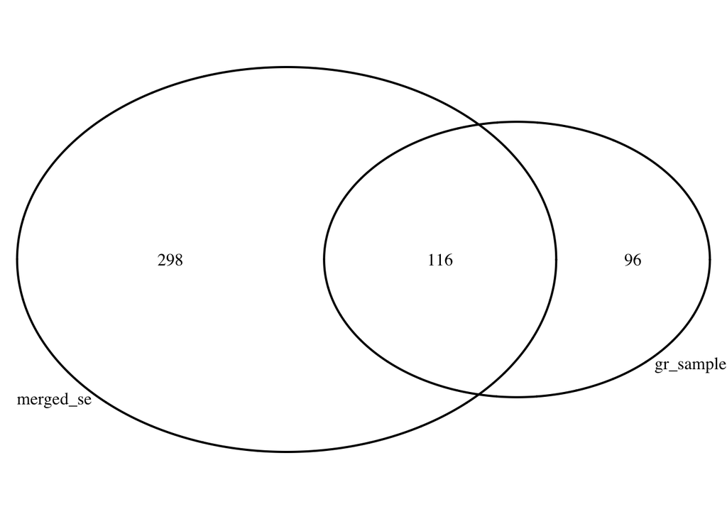

```r
grid.draw(venn.diagram(list(gr_sample=gr$var_id,
                            merged_se=names(se)),
                       filename=NULL))
```

```r
# Sanity check
length(c(unique_gr,unique_se,intersect_gr_se)) == length(union_gr_se)
```

```
## [1] TRUE
```

# 6 Select variant annotations

## 6.1 Vector of sample-independent variant annotations

These (stable) variant annotations should not change sample to sample, e.g. Ref, ALt, Gene name etc. Such annotations will be kept within metadata of the merged GRanges object.

```r
stable_annotations <- c("var_id",
"Gene.refGene","Func.refGene","ExonicFunc.refGene",
"CLNSIG","CLNREVSTAT","CLNDN",
"avsnp150","HGVS_cDNA","HGVS_Prot",
"Ref","Alt",
"CDS_Pos","TranscriptSize",
"AA_Pos","AA1","AA2","ProteinSize","Interpro_domain",
"gnomAD_genome_ALL","ExAC_ALL")

length(stable_annotations)
```

```
## [1] 21
```

## 6.2 Matrices for sample-specific variant annotations

These variant annotations may change from sample to sample, such as Genotype or Drepth etc. Such annotations will be captured and stored in additional matrices, syncronised with the GRanges object.

```r
# Score
score.mx <- matrix(NA,
                   ncol=length(se$id)+1,
                   nrow=length(union_gr_se))
rownames(score.mx) <- union_gr_se
colnames(score.mx) <- c(se$id,gr_sample_name)
head(score.mx)
```

```
##                              RMSzhang_SJRHB020 RMSzhang_SJRHB022 RMSzhang_SJRHB023
## chr1_35841278_35841278_A_C                  NA                NA                NA
## chr2_151527007_151527007_C_T                NA                NA                NA
## chr3_186081073_186081073_T_C                NA                NA                NA
## chr7_148815049_148815049_G_A                NA                NA                NA
## chr11_72003970_72003970_G_A                 NA                NA                NA
## chr4_86809827_86809827_C_T                  NA                NA                NA
```

```r
#"TruncScore"
#"HomozygScore"
#"XAcorrect"

# Other matrices

# GT
gt.mx <- matrix(NA,
                ncol=length(se$id)+1,
                nrow=length(union_gr_se))
rownames(gt.mx) <- union_gr_se
colnames(gt.mx) <- c(se$id,gr_sample_name)
head(gt.mx)
```

```
##                              RMSzhang_SJRHB020 RMSzhang_SJRHB022 RMSzhang_SJRHB023
## chr1_35841278_35841278_A_C                  NA                NA                NA
## chr2_151527007_151527007_C_T                NA                NA                NA
## chr3_186081073_186081073_T_C                NA                NA                NA
## chr7_148815049_148815049_G_A                NA                NA                NA
## chr11_72003970_72003970_G_A                 NA                NA                NA
## chr4_86809827_86809827_C_T                  NA                NA                NA
```

```r
#"Depth"
#"AD"
```

# 7 Process non-overlapping variants

## 7.1 GRanges

```r
unique_gr.gr <- gr[unique_gr,stable_annotations]
summary(unique_gr.gr)
```

```
## [1] "GRanges object with 96 ranges and 21 metadata columns"
```

```r
unique_se.gr <- rowRanges(se)[unique_se,stable_annotations]
summary(unique_se.gr)
```

```
## [1] "GRanges object with 298 ranges and 21 metadata columns"
```

## 7.2 Matrices

```r
score.mx[unique_gr, gr_sample_name] <- as.data.frame(gr[unique_gr,])$Score
gt.mx[unique_gr, gr_sample_name] <- as.data.frame(gr[unique_gr,])$GT

score.mx[unique_se, se$id] <- assay(se,"scores")[unique_se,]
gt.mx[unique_se, se$id] <- assay(se,"genotypes")[unique_se,]

rm(unique_gr,unique_se)
```

# 8 Process overlapping variants

## 8.1 Granges

Check that the stable annotations are the same before making GRange

```r
# Get intersect ranges from both samples
intersect_gr.gr <- gr[intersect_gr_se,stable_annotations]
summary(intersect_gr.gr)
```

```
## [1] "GRanges object with 116 ranges and 21 metadata columns"
```

```r
intersect_se.gr <- rowRanges(se)[intersect_gr_se,stable_annotations]
summary(intersect_se.gr)
```

```
## [1] "GRanges object with 116 ranges and 21 metadata columns"
```

```r
# Check that intersect ranges from both samples are equal
if (!all(intersect_gr.gr==intersect_se.gr)) {
  stop("GRanges shared elements differ", ok)
}

# Save the intersect
intersect_gr_se.gr <- intersect_gr.gr

# Clean-up
rm(intersect_gr.gr,intersect_se.gr,stable_annotations)
```

## 8.2 Matrices

```r
score.mx[intersect_gr_se,gr_sample_name] <- as.data.frame(gr[intersect_gr_se,])$Score
gt.mx[intersect_gr_se,gr_sample_name] <- as.data.frame(gr[intersect_gr_se,])$GT

score.mx[intersect_gr_se,se$id] <- assay(se,"scores")[intersect_gr_se,]
gt.mx[intersect_gr_se,se$id] <- assay(se,"genotypes")[intersect_gr_se,]

rm(intersect_gr_se,gr)
```

# 9 Combine overlapping and non-overlapping granges

```r
# Combine granges
gr_se.gr <- c(unique_gr.gr,unique_se.gr,intersect_gr_se.gr)

# Sort granges
gr_se.gr <- sort(gr_se.gr)

# Update matrices to keep order consistent with GRange
score.mx <- score.mx[gr_se.gr$var_id,]
gt.mx <- gt.mx[gr_se.gr$var_id,]

# Check result
summary(gr_se.gr)
```

```
## [1] "GRanges object with 510 ranges and 21 metadata columns"
```

```r
seqinfo(gr_se.gr)
```

```
## Seqinfo object with 25 sequences (1 circular) from hg38 genome:
##   seqnames seqlengths isCircular genome
##   chr1      248956422      FALSE   hg38
##   chr2      242193529      FALSE   hg38
##   chr3      198295559      FALSE   hg38
##   chr4      190214555      FALSE   hg38
##   chr5      181538259      FALSE   hg38
##   ...             ...        ...    ...
##   chr21      46709983      FALSE   hg38
##   chr22      50818468      FALSE   hg38
##   chrX      156040895      FALSE   hg38
##   chrY       57227415      FALSE   hg38
##   chrM          16569       TRUE   hg38
```

```r
# Compare with matrices
gr_se.gr[,1:2]
```

```
## GRanges object with 510 ranges and 2 metadata columns:
##                                seqnames    ranges strand |                       var_id Gene.refGene
##                                   <Rle> <IRanges>  <Rle> |                  <character>  <character>
##       chr1_7738307_7738307_C_T     chr1   7738307      * |     chr1_7738307_7738307_C_T       CAMTA1
##     chr1_17033181_17033181_C_A     chr1  17033181      * |   chr1_17033181_17033181_C_A         SDHB
##     chr1_17044726_17044726_C_T     chr1  17044726      * |   chr1_17044726_17044726_C_T         SDHB
##     chr1_23691787_23691787_C_G     chr1  23691787      * |   chr1_23691787_23691787_C_G        RPL11
##     chr1_35832419_35832419_T_-     chr1  35832419      * |   chr1_35832419_35832419_T_-         AGO4
##                            ...      ...       ...    ... .                          ...          ...
##   chrX_119640671_119640671_C_T     chrX 119640671      * | chrX_119640671_119640671_C_T        SEPT6
##   chrX_133704278_133704278_A_-     chrX 133704278      * | chrX_133704278_133704278_A_-         GPC3
##   chrX_147928745_147928745_A_C     chrX 147928745      * | chrX_147928745_147928745_A_C         FMR1
##   chrX_154368109_154368109_C_T     chrX 154368109      * | chrX_154368109_154368109_C_T         FLNA
##   chrX_154766321_154766321_G_T     chrX 154766321      * | chrX_154766321_154766321_G_T         DKC1
##   -------
##   seqinfo: 25 sequences (1 circular) from hg38 genome
```

```r
score.mx[1:5,]
```

```
##                            RMSzhang_SJRHB020 RMSzhang_SJRHB022 RMSzhang_SJRHB023
## chr1_7738307_7738307_C_T                  NA          0.540157                NA
## chr1_17033181_17033181_C_A                 0          0.000000                 0
## chr1_17044726_17044726_C_T                 0                NA                NA
## chr1_23691787_23691787_C_G                 0          0.000000                NA
## chr1_35832419_35832419_T_-                 0          0.000000                NA
```

```r
gt.mx[1:5,]
```

```
##                            RMSzhang_SJRHB020 RMSzhang_SJRHB022 RMSzhang_SJRHB023
## chr1_7738307_7738307_C_T   NA                "Ref/Alt1"        NA
## chr1_17033181_17033181_C_A "Alt1/Alt1"       "Alt1/Alt1"       "Ref/Alt1"
## chr1_17044726_17044726_C_T "Ref/Alt1"        NA                NA
## chr1_23691787_23691787_C_G "Alt1/Alt1"       "Alt1/Alt1"       NA
## chr1_35832419_35832419_T_- "Ref/Alt1"        "Ref/Alt1"        NA
```

```r
# Clean-up
rm(union_gr_se,unique_gr.gr,unique_se.gr,intersect_gr_se.gr)
```

# 10 Save to SummarizedExperiment

The combination of matrices and GRanges may be stored in **SummarizedExperiment** class for consistency with existent Bioconductor solutions:

- http://bioconductor.org/packages/release/bioc/html/SummarizedExperiment.html
- http://bioconductor.org/packages/release/bioc/vignettes/SummarizedExperiment/inst/doc/SummarizedExperiment.html

```r
# Sanity checks: that objects are in sync
if (any(colnames(gt.mx) != colnames(score.mx))) {
  stop("Matrices have different samples", ok)
}

if (any(rownames(gt.mx) != rownames(score.mx))) {
  stop("Matrices have different variants", ok)
}

if (any(names(gr_se.gr) != rownames(gt.mx))) {
  stop("Matrices and GRanges have different variants", ok)
}

# Prepare samples info
samples <- c(se$id,gr_sample_name)
files <- c(se$file,gr_sample_file)
study <- c(se$study,gr_sample_study)
samples.df <- DataFrame(id=samples, file=files ,study=study, row.names=samples)
samples.df
```

```
## DataFrame with 3 rows and 3 columns
##                                  id                                            file       study
##                         <character>                                     <character> <character>
## RMSzhang_SJRHB020 RMSzhang_SJRHB020 RMSzhang_SJRHB020_hg38.bwa.QC.scores.filter.txt       Zheng
## RMSzhang_SJRHB022 RMSzhang_SJRHB022 RMSzhang_SJRHB022_hg38.bwa.QC.scores.filter.txt       Zheng
## RMSzhang_SJRHB023 RMSzhang_SJRHB023 RMSzhang_SJRHB023_hg38.bwa.QC.scores.filter.txt       Zheng
```

```r
# Make some metadata (optional)
metadata.ls <- list(blabla="Bla Bla Bla",source="Made from GR and SE")

# Put all data to a SummarizedExperiment container
new_merged.se <- SummarizedExperiment(assays=list(genotypes=gt.mx,scores=score.mx),
                     rowRanges=gr_se.gr, colData=samples.df, metadata=metadata.ls)

# Explore result
new_merged.se
```

```
## class: RangedSummarizedExperiment
## dim: 510 3
## metadata(2): blabla source
## assays(2): genotypes scores
## rownames(510): chr1_7738307_7738307_C_T chr1_17033181_17033181_C_A ... chrX_154368109_154368109_C_T chrX_154766321_154766321_G_T
## rowData names(21): var_id Gene.refGene ... gnomAD_genome_ALL ExAC_ALL
## colnames(3): RMSzhang_SJRHB020 RMSzhang_SJRHB022 RMSzhang_SJRHB023
## colData names(3): id file study
```

```r
metadata(new_merged.se)
```

```
## $blabla
## [1] "Bla Bla Bla"
##
## $source
## [1] "Made from GR and SE"
```

```r
head(assays(new_merged.se)$scores)
```

```
##                            RMSzhang_SJRHB020 RMSzhang_SJRHB022 RMSzhang_SJRHB023
## chr1_7738307_7738307_C_T                  NA          0.540157                NA
## chr1_17033181_17033181_C_A                 0          0.000000         0.0000000
## chr1_17044726_17044726_C_T                 0                NA                NA
## chr1_23691787_23691787_C_G                 0          0.000000                NA
## chr1_35832419_35832419_T_-                 0          0.000000                NA
## chr1_35841278_35841278_A_C                NA                NA         0.7047482
```

```r
dim(assays(new_merged.se)$scores)
```

```
## [1] 510   3
```

```r
head(assays(new_merged.se)$genotypes)
```

```
##                            RMSzhang_SJRHB020 RMSzhang_SJRHB022 RMSzhang_SJRHB023
## chr1_7738307_7738307_C_T   NA                "Ref/Alt1"        NA
## chr1_17033181_17033181_C_A "Alt1/Alt1"       "Alt1/Alt1"       "Ref/Alt1"
## chr1_17044726_17044726_C_T "Ref/Alt1"        NA                NA
## chr1_23691787_23691787_C_G "Alt1/Alt1"       "Alt1/Alt1"       NA
## chr1_35832419_35832419_T_- "Ref/Alt1"        "Ref/Alt1"        NA
## chr1_35841278_35841278_A_C NA                NA                "Ref/Alt1"
```

```r
dim(assays(new_merged.se)$genotypes)
```

```
## [1] 510   3
```

```r
rowRanges(new_merged.se)[,1:2]
```

```
## GRanges object with 510 ranges and 2 metadata columns:
##                                seqnames    ranges strand |                       var_id Gene.refGene
##                                   <Rle> <IRanges>  <Rle> |                  <character>  <character>
##       chr1_7738307_7738307_C_T     chr1   7738307      * |     chr1_7738307_7738307_C_T       CAMTA1
##     chr1_17033181_17033181_C_A     chr1  17033181      * |   chr1_17033181_17033181_C_A         SDHB
##     chr1_17044726_17044726_C_T     chr1  17044726      * |   chr1_17044726_17044726_C_T         SDHB
##     chr1_23691787_23691787_C_G     chr1  23691787      * |   chr1_23691787_23691787_C_G        RPL11
##     chr1_35832419_35832419_T_-     chr1  35832419      * |   chr1_35832419_35832419_T_-         AGO4
##                            ...      ...       ...    ... .                          ...          ...
##   chrX_119640671_119640671_C_T     chrX 119640671      * | chrX_119640671_119640671_C_T        SEPT6
##   chrX_133704278_133704278_A_-     chrX 133704278      * | chrX_133704278_133704278_A_-         GPC3
##   chrX_147928745_147928745_A_C     chrX 147928745      * | chrX_147928745_147928745_A_C         FMR1
##   chrX_154368109_154368109_C_T     chrX 154368109      * | chrX_154368109_154368109_C_T         FLNA
##   chrX_154766321_154766321_G_T     chrX 154766321      * | chrX_154766321_154766321_G_T         DKC1
##   -------
##   seqinfo: 25 sequences (1 circular) from hg38 genome
```

```r
colData(new_merged.se)
```

```
## DataFrame with 3 rows and 3 columns
##                                  id                                            file       study
##                         <character>                                     <character> <character>
## RMSzhang_SJRHB020 RMSzhang_SJRHB020 RMSzhang_SJRHB020_hg38.bwa.QC.scores.filter.txt       Zheng
## RMSzhang_SJRHB022 RMSzhang_SJRHB022 RMSzhang_SJRHB022_hg38.bwa.QC.scores.filter.txt       Zheng
## RMSzhang_SJRHB023 RMSzhang_SJRHB023 RMSzhang_SJRHB023_hg38.bwa.QC.scores.filter.txt       Zheng
```

```r
# Clean-up
rm(samples,files,study,samples.df,gr_se.gr,gt.mx,score.mx,
   gr_sample_name,gr_sample_file,gr_sample_study,se,
   metadata.ls)
```

# 11 Save data

```r
save.image("s02_combine_gr_an_se.RData")
```

# 12 Final section

```r
ls()
```

```
## [1] "base_folder"     "data_folder"     "gr_sample.gr"    "merged.se"       "new_merged.se"   "scripts_fiolder"
```

```r
Sys.time()
```

```
## [1] "2021-02-25 14:52:50 GMT"
```

```r
gc()
```

```
##            used  (Mb) gc trigger  (Mb) limit (Mb) max used  (Mb)
## Ncells  4969049 265.4    8710232 465.2         NA  8710232 465.2
## Vcells 12130636  92.6   20623808 157.4      16384 20622966 157.4
```

# 13 Notes

In case of further development of this approach to merging of GRanges and Summarized Experiments, the following points could be kept in mind:

- The **data types**  
  merge(GRanges, SummarisedExperiment) -> SummarisedExperiment
- The **key** for subsetting might be defined by key used to create the source SummarisedExperiment
- The **anotations** to keep in GRanges and in matrices might be defined by annotations used to create the source SummarisedExperiment